# Day 17

Author

Kasia Kedzierska

Published

December 17, 2024

Modified

December 19, 2024

Today, together with historian elves we’re falling into despair, or rather having to debug some very weird computer program. Must admit, reading the instructions the first time made me question if I want to do it. Not because the task is hard, but because the instructions are so weird. But let’s not get ahead of ourselves.

We are falling through a void and the only way to save us is to debug a 3-bit (weird I might add!) computer program. Read the whole story on the official [Day 17 of Advent of Code 2024](https://adventofcode.com/2024/day/17) website.

Here’s a ChatGPT negotiated illustration of the setup:

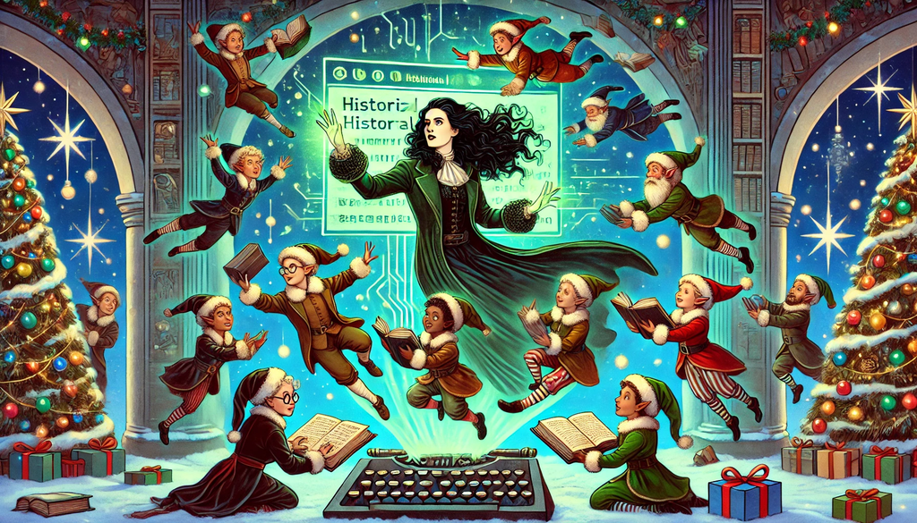

**Setting up**

```python
from misc.helper import verify_answer

example_input_file_1 = "../inputs/example_day_17_1.txt"
example_input_file_2 = "../inputs/example_day_17_2.txt"
input_file = "../inputs/day_17.txt"
```

## Part 1: Debug the debugging

We are given an input that specifies the state of input registers, and the program itself. Program is composed of 3-bit integers (0-7) separated by commas. Each pair of integers represent an `instruction` and an `operand`. An operand can be a `literal` operand, or can be a `combo` operand. Literal operand is just the number itself, while `combo` operand follows its separate rules. Whether an `operand` should be treated as a `literal` or a `combo` operand is determined by the instruction.

**Combo operands**:  
* `0` - `3` - same as `literal` operand.  
* `4` - value of register `A`.  
* `5` - value of register `B`.  
* `6` - value of register `C`.  
* `7` - is reserved and does not appear as combo operand.

**Instructions**:  
* `0` - division of value in register `A` by the 2 to the power of its `combo` operand; The result truncated to integer is stored in register `A`.  
* `1` - bitwise XOR of register `B` and `literal` operand; The result is stored in register `B`.  
* `2` - calculates its `combo` operand module 8 and saves it in register `B`.  
* `3` - does nothing if register `A` is 0, but if register `A` is not 0, it jumps to the instruction specified by its `literal` operand.  
* `4` - bitwise XOR of register `B` and register `C` and stores the result in register `B`.  
* `5` - calculates `combo` operand modulo 8 and outputs the result.  
* `6` - division of value in register `A` by the 2 to the power of its `combo` operand; The result truncated to integer is stored in register `B`.  
* `7` - division of value in register `A` by the 2 to the power of its `combo` operand; The result truncated to integer is stored in register `C`.

```python
# bitwise xor in python
def xor(a, b):
    return a ^ b
```

```python
import re
from pathlib import Path


def parse_input(input):
    if Path(input).exists():
        input = Path(input).read_text()
    registers = {}
    for line in input.strip().split("\n"):
        if line.startswith("Register"):
            # extract regster letter from "Register X:"
            register = re.findall(r"Register (\w):", line)[0]
            registers[register] = int(line.split(": ")[1])
        elif line.startswith("Program"):
            program = [int(el) for el in line.split(": ")[1].split(",")]

    return registers, program


example = """
Register A: 17
Register B: 21
Register C: 3

Program: 0,1,2,3,5,3
"""

parse_input(example)
```

```
({'A': 17, 'B': 21, 'C': 3}, [0, 1, 2, 3, 5, 3])
```

```python
def execute_program(program, registers):
    program = program.copy()
    registers = registers.copy()

    def combo_operand(operand: int):
        match operand:
            case x if x < 4:  # Guard clause for values less than 4
                return operand
            case 4:
                return registers["A"]
            case 5:
                return registers["B"]
            case 6:
                return registers["C"]
            case 7:
                raise ValueError("Invalid operand")
            case _:
                raise ValueError("Operand not recognized")

    i = 0
    out = []
    while i < len(program):
        match program[i]:
            case 0:
                registers["A"] = int(
                    registers["A"] / 2 ** combo_operand(program[i + 1])
                )
                i += 2
            case 1:
                registers["B"] = xor(registers["B"], program[i + 1])
                i += 2
            case 2:
                registers["B"] = combo_operand(program[i + 1]) % 8
                i += 2
            case 3:
                if registers["A"] == 0:
                    i += 2
                else:
                    i = program[i + 1]
            case 4:
                registers["B"] = xor(registers["B"], registers["C"])
                i += 2
            case 5:  # out
                out.append(combo_operand(program[i + 1]) % 8)
                i += 2
            case 6:
                registers["B"] = int(
                    registers["A"] / 2 ** combo_operand(program[i + 1])
                )
                i += 2
            case 7:
                registers["C"] = int(
                    registers["A"] / 2 ** combo_operand(program[i + 1])
                )
                i += 2
            case _:
                raise ValueError("Invalid instruction")
    return ",".join(map(str, out))
```

```python
def part_one(input):
    registers, program = parse_input(input)
    return execute_program(program, registers)
```

```python
verify_answer(part_one, example, "3")
```

```
✔️ That's right! The answer is 3.
```

```python
verify_answer(part_one, example_input_file_1, "4,6,3,5,6,3,5,2,1,0")
```

```
✔️ That's right! The answer is 4,6,3,5,6,3,5,2,1,0.
```

```python
%time part_one(input_file)
```

```
CPU times: user 515 μs, sys: 601 μs, total: 1.12 ms
Wall time: 780 μs
```

```
'1,5,3,0,2,5,2,5,3'
```

> That’s the right answer! You are one gold star ⭐ closer to finding the Chief Historian.